# Coupling mineMS2 to GNPS molecular networks

Alexis Delabrière, Coline Gianfrotta and Etienne Thévenot

2025-06-19

#### Package

mineMS2 1.0.0

# 1 Introduction

This vignette describes how *mineMS2* can be **coupled to the GNPS MS/MS molecular networking** methodology (Watrous et al. 2012) to **focus on patterns that best explain components** of the network. We strongly recommend to **compute the patterns and the GNPS network using the same .mgf input file** to avoid matching issues. In this example, the molecular network has been precomputed on the GNPS website and extracted in the *GraphML* format (file *pnordicum_ms2_gnps.graphml* inside the *dataset* subdirectory of the *mineMS2* installation folder).

# 2 Pre-requisites

## 2.1 Data set

The dataset contains **51 MS/MS spectra** from secondary metabolites of *Penicillium nordicum* (one spectrum per compound) acquired on an HPLC system (Luna C18 column; Phenomenex) coupled to an LTQ Orbitrap XL hybrid (Thermo Fisher Scientific) operated in the positive ionization mode at a HCD20 collision energy and a resolution of 7,500 (Hautbergue et al. 2019).

## 2.2 Initialization

The 3 file names of the **spectra data, metadata, and molecular network** are:

```r
if (!require(mineMS2)) install_github("odisce/mineMS2")
library(mineMS2)

data_dir.c <- system.file("dataset",package = "mineMS2")
spectra_file.c <- file.path(data_dir.c, "pnordicum_ms2_spectra.mgf")
metadata_file.c <- file.path(data_dir.c, "pnordicum_ms2_info.tsv")
network_file.c <- file.path(data_dir.c, "pnordicum_ms2_gnps.graphml")
```

An **`ms2Lib`** object is then initialized with the spectra data (and optionally, metadata). This object will be used throughout the workflow to compute and store the m/z differences, the fragmentation graphs, and the patterns. Note that two additional *mz.precursor* and *file* columns are automatically included in the metadata table stored in the `ms2Lib` object with the information from the *mgf* file.

```r
metadata.df <- read.table(metadata_file.c,
                          header = TRUE,
                          sep = "\t")

# Building the ms2Lib object and storing the spectra data (and metadata)
pnordicum.m2l <- ms2Lib(spectra_file.c, suppInfos = metadata.df)
```

```
## Reading MGF file C:/Users/et207099/AppData/Local/R/win-library/4.3/mineMS2/dataset/pnordicum_ms2_spectra.mgf.
```

```r
head(getInfo(pnordicum.m2l, "S"))
```

```
##    mz.precursor
## S1     481.2905
## S2     481.2905
## S3     147.0649
## S4     213.1120
## S5     215.1277
## S6     231.1226
##                                                                                           file
## S1 C:/Users/et207099/AppData/Local/R/win-library/4.3/mineMS2/dataset/pnordicum_ms2_spectra.mgf
## S2 C:/Users/et207099/AppData/Local/R/win-library/4.3/mineMS2/dataset/pnordicum_ms2_spectra.mgf
## S3 C:/Users/et207099/AppData/Local/R/win-library/4.3/mineMS2/dataset/pnordicum_ms2_spectra.mgf
## S4 C:/Users/et207099/AppData/Local/R/win-library/4.3/mineMS2/dataset/pnordicum_ms2_spectra.mgf
## S5 C:/Users/et207099/AppData/Local/R/win-library/4.3/mineMS2/dataset/pnordicum_ms2_spectra.mgf
## S6 C:/Users/et207099/AppData/Local/R/win-library/4.3/mineMS2/dataset/pnordicum_ms2_spectra.mgf
##    id       mz    rt group polarity id_file         name  formula corrected_rt
## S1  1 481.2905 43.82     B      pos       1                  <NA>        43.82
## S2  2 481.2905 44.16     B      pos       1                  <NA>        44.22
## S3  3 147.0640  3.12     B      pos       3  Verrucolone  C6H10O4         3.12
## S4  4 213.1119 15.65     B      pos       3         PC-2 C11H16O4        15.75
## S5  5 215.1276 13.91     B      pos       3 LL-P880alpha C11H18O4        13.94
## S6  6 231.1227  5.66     B      pos       3 LL-P880 beta C11H18O5         5.66
##    fungisporins N
## S1              1
## S2              2
## S3              3
## S4              4
## S5              5
## S6              6
```

```r
# Specifying the IDs of the spectra (optional, for display only)
metadata.df <- getInfo(pnordicum.m2l,"S")
ids <- paste(paste("MZ",metadata.df[,"mz"]), paste0("RT",metadata.df[,"rt"]), sep = "_")
pnordicum.m2l <- setIds(pnordicum.m2l,ids)
```

## 2.3 Mining patterns

The mining of patterns (graphs of m/z differences) in the spectra data is detailed in the *mineMS2_main* vignette. Briefly,

1. Building the **fragmentation graph** of each spectrum (`discretizeMzDifferences`)
   1. computing and aligning **all m/z differences** within the spectra for the whole library
   2. building the fragmentation graphs
2. **Extracting common patterns** between fragmentation graphs (`mineClosedSubgraphs`)

```r
# Building the fragmentation graphs
pnordicum.m2l <- discretizeMzDifferences(pnordicum.m2l, dmz = 0.007, ppm = 15,
                                         maxFrags = 15)
```

```
## Time difference of 11.82323 secs
## Time difference of 0.021034 secs
## Time difference of 2.200104 secs
## Time difference of 4.26563 secs
```

```r
# Extracting the patterns
pnordicum.m2l <- mineClosedSubgraphs(pnordicum.m2l, sizeMin = 1, count = 2)
```

A total of 290 patterns are detected. The exploration of these patterns with the *mineMS2* methods (including `findMz`, `select`, `plotPatterns`) is described in the *mineMS2_main* vignette.

Here we focus on **patterns that best explain components of the molecular network** from the same spectra.

# 3 Coupling mineMS2 to GNPS molecular networks

## 3.1 Loading the molecular network

The **molecular network** is read using the *igraph* package:

```r
library(igraph)

molnet.igraph <- read_graph(network_file.c, "graphml")
```

Since self-edges (i.e. single loops) are automatically added by GNPS to single nodes, we use the `simplify` function from the *igraph* package to remove these edges. We also use the `as_undirected` function to remove edge directions.

```r
molnet.igraph <- simplify(molnet.igraph, remove.multiple = FALSE,
                          edge.attr.comb = "ignore")
molnet.igraph <- as_undirected(molnet.igraph, mode = "each")
```

An overview of the GNPS network after this processing is shown below (as visualized with the [**Cytoscape**](https://cytoscape.org/) software (Shannon et al. 2003)):

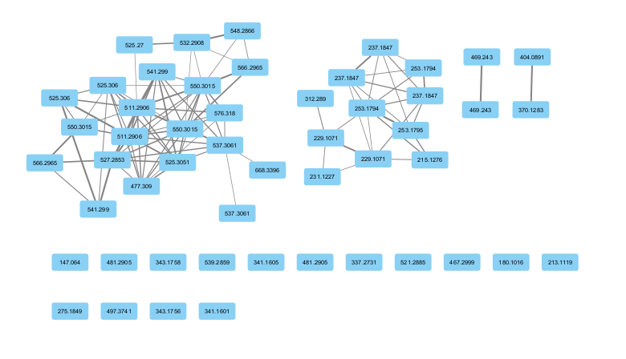

Two clusters (of size 21 and 11, respectively) are detected by GNPS, in addition to 2 pairs. In the remainder of the vignette, we show how to **select and interpret patterns specific of components from the molecular network**.

## 3.2 Extracting components from the molecular network (`findGNPSComponents`)

We consider 3 type of components of the network:

- the **connected components** of the graph (subgraphs in which any two nodes are connected by a path)
- the **cliques** (subgraphs in which any all pairs of nodes are connected)

  Instead of computing all the cliques from the network, **mineMS2 selects a set of disjoint cliques** (i.e. cliques without any nodes in common) by decreasing number of size (nodes): the algorithm starts with the biggest clique, then searches for the biggest clique that does not contain any node of this first clique, and so on until no clique is left
- the **high similarity pairs of nodes** (pairs of spectra with a cosine score superior to a threshold)

  Note that only similarity pairs out of the previous selected cliques are selected

**All these components can be extracted** using the **`findGNPSComponents`** function, with the main parameters:

1. `minSize`: minimum size of the detected cliques

2. `pairThreshold`: threshold of the cosine score for high similarity pairs of nodes

Note: the parameters `vname` and `eattr` indicate the names of the node ids and edge similarity measure in the molecular network according to the software used: these attributes are named *cluster index* and *EdgeScore* in GNPS networks, and *shared name* and *cosine_score* in MetGem (Olivon et al. 2018).

```r
molnet_comp.ls <- findGNPSComponents(molnet.igraph, minSize = 3, pairThreshold = 0.9,
                                     vname = "cluster index", eattr = "EdgeScore")
```

```r
molnet_comp.ls
```

```
## [[1]]
## [1] 37 22 25 38 34 21 28 31
##
## [[2]]
## [1] 10  8  7 46  9
##
## [[3]]
## [1] 27 26 33
##
## [[4]]
## [1] 29 40 35
##
## [[5]]
## [1] 45 44  6
##
## [[6]]
##  [1] 40 22 33 24 30 28 21 36 35 31 41 27 37 42 34 39 26 38 25 29 51
##
## [[7]]
##  [1] 44 12  5  8 46  9 47  7  6 45 10
##
## [[8]]
## [1] 18 17
##
## [[9]]
## [1] 50 49
##
## $`39 (-) 36`
## [1] 39 36
##
## $`10 (-) 47`
## [1] 10 47
```

Components 6, 7, 8 and 9 are the connected components of the network (2 clusters and 2 pairs). Components 1, 3, and 4 are disjoint cliques from the component 6 (larger cluster). Components 2 and 5 are disjoint cliques from component 7 (smaller cluster).

The m/z values of the precursors from these spectra can be retrieved with:

```r
lapply(molnet_comp.ls,
       function(spec_indices.vi)
         getInfo(pnordicum.m2l, paste0("S", spec_indices.vi))[, "mz.precursor"])
```

```
## [[1]]
## [1] 550.3015 511.2906 525.3060 550.3015 541.2990 511.2906 527.2853 537.3061
##
## [[2]]
## [1] 253.1797 237.1847 237.1847 237.1847 253.1797
##
## [[3]]
## [1] 525.306 525.306 541.299
##
## [[4]]
## [1] 532.2908 566.2965 548.2866
##
## [[5]]
## [1] 229.1071 229.1071 231.1226
##
## [[6]]
##  [1] 566.2965 511.2906 541.2990 525.2700 537.3061 527.2853 511.2906 550.3015
##  [9] 548.2866 537.3061 576.3180 525.3060 550.3015 668.3396 541.2990 566.2965
## [17] 525.3060 550.3015 525.3060 532.2908 477.3090
##
## [[7]]
##  [1] 229.1071 312.2896 215.1277 237.1847 237.1847 253.1797 253.1797 237.1847
##  [9] 231.1226 229.1071 253.1797
##
## [[8]]
## [1] 404.0894 370.1283
##
## [[9]]
## [1] 469.243 469.243
##
## $`39 (-) 36`
## [1] 566.2965 550.3015
##
## $`10 (-) 47`
## [1] 253.1797 253.1797
```

## 3.3 Finding patterns explaining the extracted components (`findPatternsExplainingComponents`)

*mineMS2* then enables to select the pattern that best explain each of the extracted components according to 3 metrics (between 0 and 1). Let us call *explained spectrum* a spectrum that contains the pattern, and *component spectrum* a spectrum that belongs to the molecular network component.

- **recall**: proportion of *explained* spectra among the *component* spectra; the recall is 1 if all spectra from the component are explained
- **precision**: proportion of *component* spectra among the *explained* spectra; the precision is 1 if no spectrum outside of the component is explained
- **F1-score**: harmonic mean of the precision and recall; the F1-score is 1 if recall and precision are 1, i.e. if the pattern explains all spectra from the component and no other one

Here, we set the metric argument to `c("recall","precision","size")` to indicate that a **pattern maximizing recall is extracted for each component, precision and size being then used to split ties**. This will result in a single explaining pattern in most cases. We can however choose to return the **top-*k* best explaining patterns** for each component instead (ordered by decreasing metric value) with the argument `top`, to get additional insight about fragmentation subgraphs of interest among spectra of the component.

```r
molnet_patterns.ls <- findPatternsExplainingComponents(pnordicum.m2l, molnet_comp.ls,
                                                       metric = c("recall", "precision","size"),
                                                       top = 5)
```

The returned list contains the **metric values for the selected patterns**. For example, for the pair of spectra with precursor m/z values of $370.1283$ and $404.0891$ (component 8), the best explaining pattern P70 has an F1-score of 1, while the other patterns have still a recall of 1 but a lower precision (i.e. are less specific to this pair of spectra).

```r
molnet_patterns.ls[[8]]
```

```
##        id        f1 precision recall miss size
## P70   P70 1.0000000 1.0000000      1    0    6
## P99   P99 0.6666667 0.5000000      1    0    5
## P71   P71 0.6666667 0.5000000      1    0    4
## P110 P110 0.5714286 0.4000000      1    0    4
## P100 P100 0.4444444 0.2857143      1    0    4
```

The **ids of the best pattern** for each components can then be extracted with:

```r
sapply(molnet_patterns.ls,
       function(patterns.df)
         rownames(patterns.df)[1])
```

```
##
##    "P281"    "P134"    "P173"    "P179"     "P58"    "P188"    "P112"     "P70"
##           39 (-) 36 10 (-) 47
##    "P215"    "P160"     "P27"
```

These patterns can be **visualized** using the `plot` (to display the pattern; with a `tkplot` argument available for interactivity) and `plotOccurrences` (to display the spectra containing the pattern, also called occurrences, or support as a whole) method, which are wrapped inside the **`plotPatterns`** method for convenience. This function also generates information about the spectra and the m/z differences in the pattern. The `infos_col` parameter is used to select the spectra information to be included (if `NULL`, all the available information will be displayed). The results can be **exported** in pdf (one pdf file per pattern) by setting the `save_dir` argument to the path of the target directory for saving (default to `"none"` for no export).

Here we display the best explaining pattern P70 of component 8 (high similarity pair). We observe that the m/z values of the fragment ions are shifted between the two spectra.

|  | mz.precursor | rt | name |
| --- | --- | --- | --- |
| S17 | 370.1283 | 26.51 | Ochratoxin B |
| S18 | 404.0894 | 33.16 | Ochratoxin A |

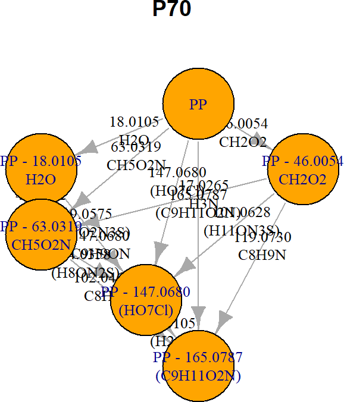

|  | Mz_diff_mean | Mz_diff_min | Mz_diff_max | Formula | Chosen_formula |
| --- | --- | --- | --- | --- | --- |
| 2 | 17.0265 | 17.0218 | 17.0312 | H3N | H3N |
| 3 | 18.0105 | 18.0059 | 18.0152 | H2O | H2O |
| 24 | 45.0212 | 45.0166 | 45.0259 | CH3ON | CH3ON |
| 26 | 46.0054 | 46.0007 | 46.0100 | CH2O2 | CH2O2 |
| 59 | 63.0319 | 63.0272 | 63.0366 | CH5O2N | CH5O2N |
| 99 | 84.0358 | 84.0312 | 84.0405 | C3H4ON2,CH9O2P,H8ON2S,CH8O4,H8O3N2 | H8ON2S |
| 130 | 101.0628 | 101.0582 | 101.0675 | C3H7ON3,CH12O2NP,H11ON3S | H11ON3S |
| 131 | 102.0469 | 102.0423 | 102.0516 | C3H6O2N2,CH11O3P,H10O2N2S,C8H6,C5H10S,C2H6ON4 | C8H6 |
| 155 | 119.0730 | 119.0683 | 119.0776 | C4H9O3N,C3H9O2N3,CH14O3NP,H13O2N3S,C8H9N,C5H13NS | C8H9N |
| 166 | 129.0575 | 129.0528 | 129.0622 | C4H7O2N3,C2H12O3NP,CH11O2N3S,C9H7N,CH13N3P2,C6H11NS,C2H11O5N,C3H15NS2,CH12O2N3P,C6H11O2N,C3H15O2NS | CH11O2N3S |
| 187 | 147.0680 | 147.0633 | 147.0726 | H9O6N3,C5H9O4N,C6H5N5,C4H10ON3P,C2H13O4NS,H5ON9,C4H9O3N3,C2H14O4NP,C3H10N5P,CH13O3N3S,C9H9ON,CH15ON3P2,HO7Cl,H14N5SP,C6H13ONS,C3H17ONS2,C3H9O2N5 | HO7Cl |
| 187.1 | 147.0680 | 147.0633 | 147.0726 | H9O6N3,C5H9O4N,C6H5N5,C4H10ON3P,C2H13O4NS,H5ON9,C4H9O3N3,C2H14O4NP,C3H10N5P,CH13O3N3S,C9H9ON,CH15ON3P2,HO7Cl,H14N5SP,C6H13ONS,C3H17ONS2,C3H9O2N5 | C9H9ON |
| 202 | 165.0787 | 165.0740 | 165.0833 | C4H11O4N3,C5H7N7,C2H16O5NP,C3H12ON5P,CH15O4N3S,C9H11O2N,CH17O2N3P2,H3O8Cl,C2H11N7S,C6H15O2NS | C9H11O2N |

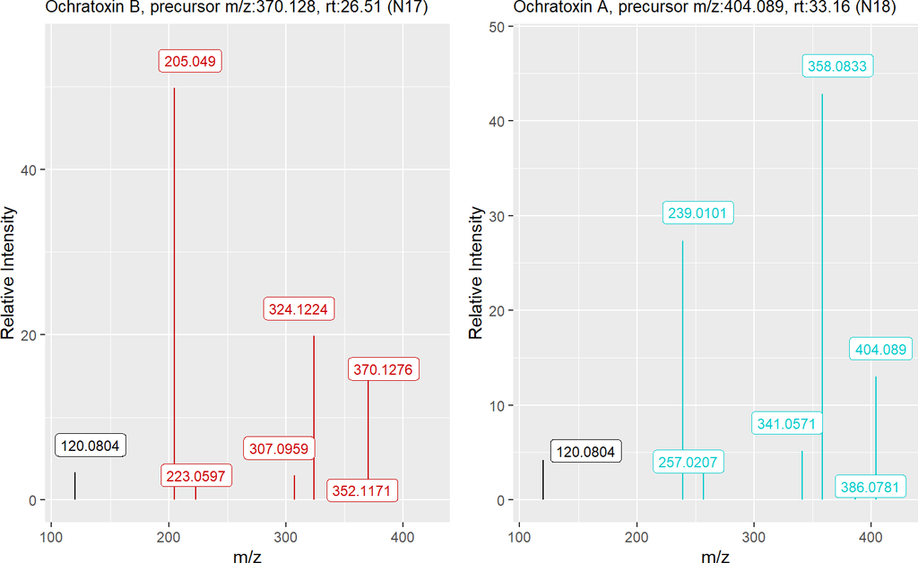

```r
plotPatterns(pnordicum.m2l, molnet_patterns.ls[[8]][1, "id"],
             infos_col = c("mz.precursor", "rt", "name"))
```

## 3.4 Annotating the molecular network with the best explaining patterns (`annotateNetwork`)

The information about each best explaining pattern (i.e. the explained component, the pattern id, the metric values) can be added to the network object and exported as a *GraphML* file for visualization in Cytoscape.

```r
molnet_annot.igraph <- annotateNetwork(molnet_comp.ls, molnet.igraph,
                                       molnet_patterns.ls)
```

The **annotated network** can be exported using the `write_graph` function from the *igraph* package.

```r
write_graph(graph = molnet_annot.igraph, format = "graphml",
            file = file.path(getwd(),
                             "pnordicum_ms2_gnps_mined.graphml"))
```

This network can be **visualized with Cytoscape** (note that the *GraphML* format is supported by Cytoscape 3: select ‘File > Import > Network from file’; with Cytoscape 2, the GraphMLReader plugin is needed):

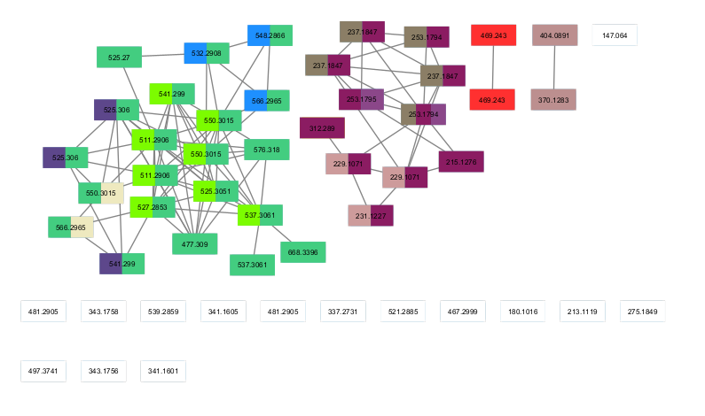

To visualize the colors, the *enhancedGraphics* App from Cytoscape is required (‘Apps > Install Apps > Search: enhanced Graphics’). Then, in the *Style* tab from the *Control Panel*, select for the *Image/Chart 1* the *Column: colorComponents* and the *Mapping Type: Passthrough Mapping*. Each component is assigned a color: note that the node (i.e. the spectra) may belong to several components.

## 3.5 Interpreting the components in terms of fragmentation patterns

We can now interpret the molecular network in terms of fragmentation patterns.

We first investigate the pattern best explaining the largest component (6 consisting of 21 spectra, including:

- data frame with the metrics values (single row)

```r
comp6_pattern_metrics.df <- molnet_patterns.ls[[6]][1, ]
comp6_pattern_metrics.df
```

```
##        id   f1 precision    recall      miss size
## P188 P188 0.95         1 0.9047619 0.0952381    2
```

- id of the pattern

```r
comp6_pattern_id.c <- comp6_pattern_metrics.df[, "id"]
comp6_pattern_id.c
```

```
## [1] "P188"
```

- information about the pattern

```r
infoPatterns(pnordicum.m2l, comp6_pattern_id.c)
```

```
##     mz.precursor id       mz    rt group polarity id_file
## S21     511.2906 21 511.2906 17.90     B      pos       4
## S22     511.2906 22 511.2906 18.57     B      pos       4
## S24     525.2700 24 525.2700 25.82     B      pos       4
## S25     525.3060 25 525.3051 19.55     B      pos       4
## S26     525.3060 26 525.3060 20.20     B      pos       4
## S27     525.3060 27 525.3060 20.92     B      pos       4
## S28     527.2853 28 527.2853 12.75     B      pos       4
## S29     532.2908 29 532.2908 36.36     B      pos       4
## S31     537.3061 31 537.3061 23.07     B      pos       4
## S33     541.2990 33 541.2990 15.43     B      pos       4
## S34     541.2990 34 541.2990 13.84     B      pos       4
## S35     548.2866 35 548.2866 29.45     B      pos       4
## S36     550.3015 36 550.3015 17.09     B      pos       4
## S37     550.3015 37 550.3015 17.84     B      pos       4
## S38     550.3015 38 550.3015 18.93     B      pos       4
## S39     566.2965 39 566.2965 12.26     B      pos       4
## S40     566.2965 40 566.2965 13.24     B      pos       4
## S41     576.3180 41 576.3180 21.00     B      pos       4
## S51     477.3090 51 477.3090 16.92     B      pos       7
##                                name    formula corrected_rt fungisporins  N
## S21        Hydrolyzed fungisporin A C28H38N405        17.90        known 21
## S22          Hydrolyzed Cyclo(VFVF) C28H38N4O5        18.57        known 22
## S24                   Cyclo(R1 VVF) C28H36N4O6        25.82      unknown 24
## S25     Hydrolyzed Cyclo(FFVI) IFFV C29H40N4O5        19.55        known 25
## S26     Hydrolyzed Cyclo(FFIV) VFFI C29H40N4O5        20.20        known 26
## S27                                       <NA>        20.92              27
## S28        Hydrolyzed fungisporin B C28H38N4O6        12.75        known 28
## S29                   Fungisporin D C30H37N5O4        36.36        known 29
## S31   Hydrolyzed Cyclo(VR2FV) VR2FV C28H42N4O5        23.07      unknown 31
## S33          Hydrolyzed Cyclo(YFIV) C29H40N4O6        15.43        known 33
## S34          Hydrolyzed Cyclo(YFVI) C29H40N4O6        13.84        known 34
## S35                     Cyclo(YWVV) C30H37N5O5        29.45        known 35
## S36   Hydrolyzed Fungisporin D VFWV C30H39N5O5        17.09        known 36
## S37   Hydrolyzed Fungisporin D VFWV C30H39N5O5        17.84              37
## S38   Hydrolyzed Fungisporin D WVVF C30H39N5O5        18.93        known 38
## S39      Hydrolyzed Cyclo(YWVV)VYWV C30H39N5O6        12.26        known 39
## S40     Hydrolyzed Cyclo(YWVV) WVVY C30H39N5O6        13.24        known 40
## S41 Hydrolyzed Cyclo(R1R2VF) R1R2VF C30H43N5O5        21.00      unknown 41
## S51     Hydrolyzed Cyclo(VIVF) VIVF C25H40N4O5        16.92      unknown 51
```

- display of the pattern

|  | mz.precursor | rt | name |
| --- | --- | --- | --- |
| S21 | 511.2906 | 17.90 | Hydrolyzed fungisporin A |
| S22 | 511.2906 | 18.57 | Hydrolyzed Cyclo(VFVF) |
| S24 | 525.2700 | 25.82 | Cyclo(R1 VVF) |
| S25 | 525.3060 | 19.55 | Hydrolyzed Cyclo(FFVI) IFFV |
| S26 | 525.3060 | 20.20 | Hydrolyzed Cyclo(FFIV) VFFI |
| S27 | 525.3060 | 20.92 |  |
| S28 | 527.2853 | 12.75 | Hydrolyzed fungisporin B |
| S29 | 532.2908 | 36.36 | Fungisporin D |
| S31 | 537.3061 | 23.07 | Hydrolyzed Cyclo(VR2FV) VR2FV |
| S33 | 541.2990 | 15.43 | Hydrolyzed Cyclo(YFIV) |
| S34 | 541.2990 | 13.84 | Hydrolyzed Cyclo(YFVI) |
| S35 | 548.2866 | 29.45 | Cyclo(YWVV) |
| S36 | 550.3015 | 17.09 | Hydrolyzed Fungisporin D VFWV |
| S37 | 550.3015 | 17.84 | Hydrolyzed Fungisporin D VFWV |
| S38 | 550.3015 | 18.93 | Hydrolyzed Fungisporin D WVVF |
| S39 | 566.2965 | 12.26 | Hydrolyzed Cyclo(YWVV)VYWV |
| S40 | 566.2965 | 13.24 | Hydrolyzed Cyclo(YWVV) WVVY |
| S41 | 576.3180 | 21.00 | Hydrolyzed Cyclo(R1R2VF) R1R2VF |
| S51 | 477.3090 | 16.92 | Hydrolyzed Cyclo(VIVF) VIVF |

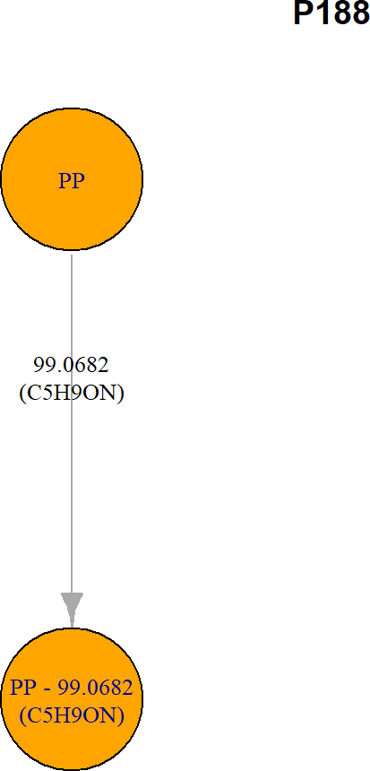

| Mz_diff_mean | Mz_diff_min | Mz_diff_max | Formula | Chosen_formula |
| --- | --- | --- | --- | --- |
| 99.0682 | 99.0635 | 99.0728 | H9O3N3,C5H9ON,C2H13ONS | C5H9ON |

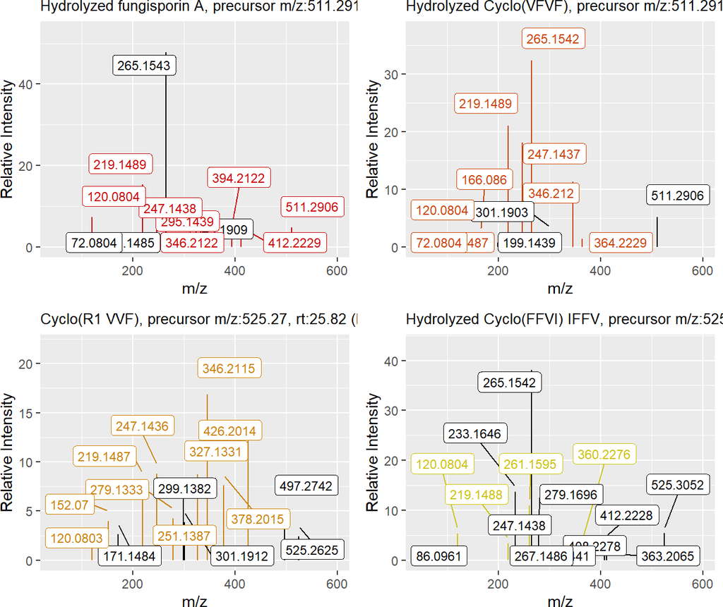

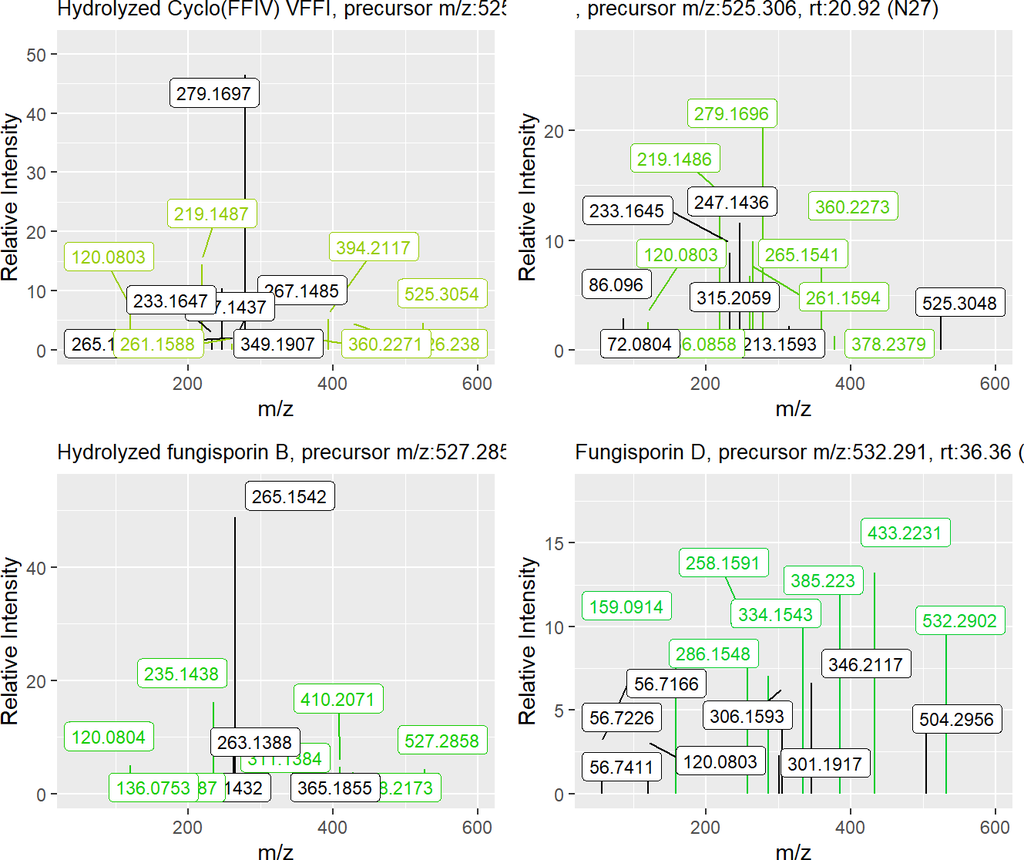

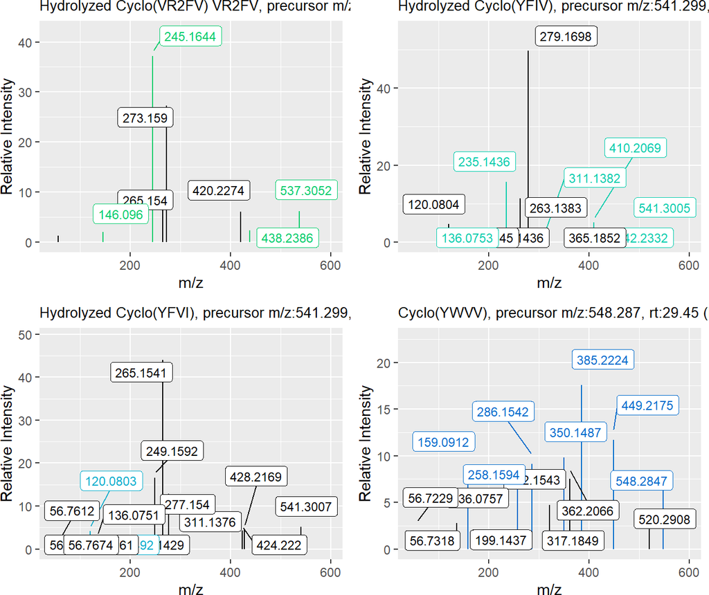

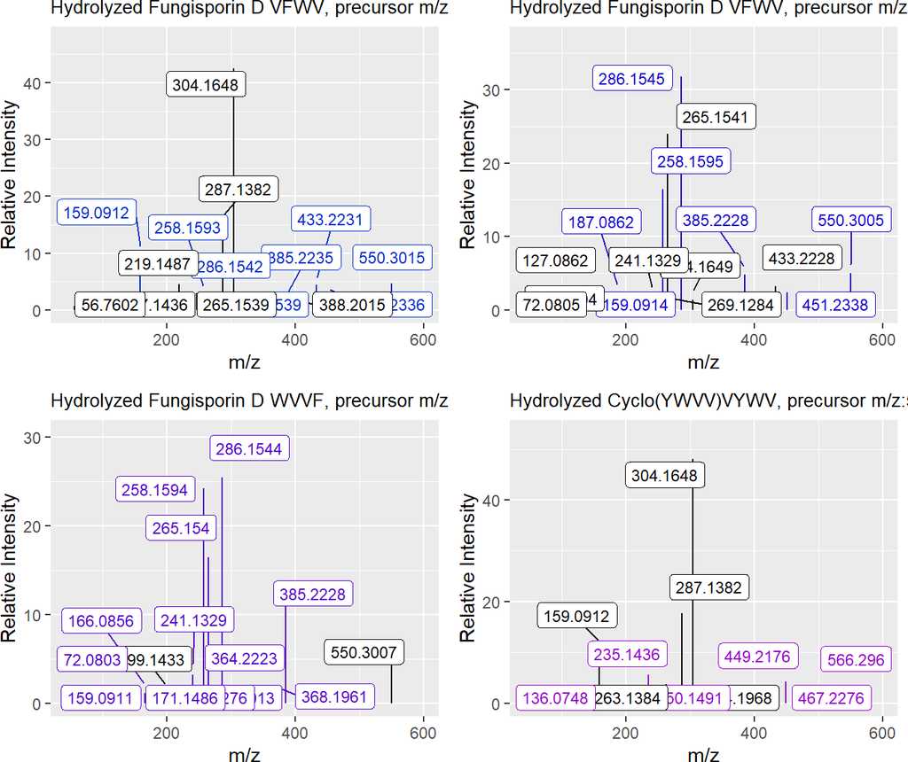

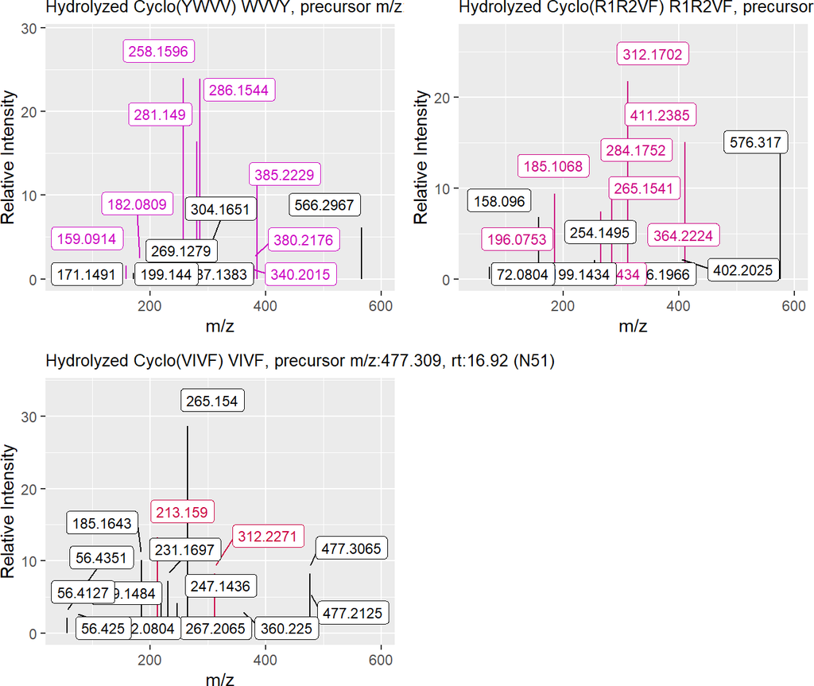

```r
plotPatterns(pnordicum.m2l, comp6_pattern_metrics.df[, "id"],
             infos_col = c("mz.precursor", "rt", "name"))
```

We see that 19 out of the 21 fragmentation spectra share an m/z difference of $99.0683$, that is not present in any other spectra of the data set (precision = 1). The closest formula for this m/z difference, $C_5H_9ON$, could correspond to a loss of valine, which is consistent with the metabolites of this component are tetrapeptides including a valine residue.

As another example within this cluster, the circled clique in the figure below (component 4) is explained by a larger pattern:

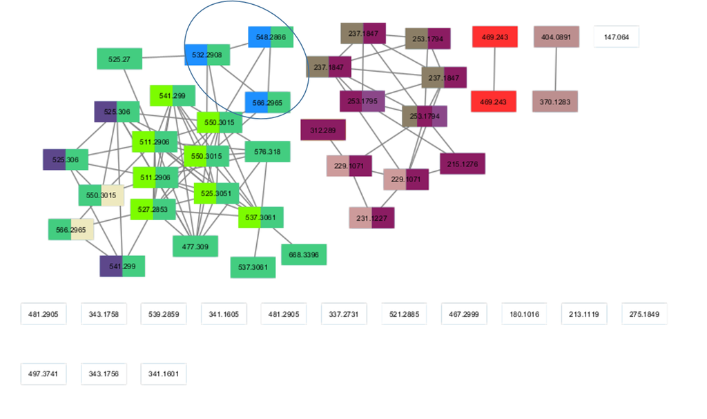

|  | mz.precursor | rt | name | formula |
| --- | --- | --- | --- | --- |
| S29 | 532.2908 | 36.36 | Fungisporin D | C30H37N5O4 |
| S35 | 548.2866 | 29.45 | Cyclo(YWVV) | C30H37N5O5 |
| S38 | 550.3015 | 18.93 | Hydrolyzed Fungisporin D WVVF | C30H39N5O5 |
| S40 | 566.2965 | 13.24 | Hydrolyzed Cyclo(YWVV) WVVY | C30H39N5O6 |

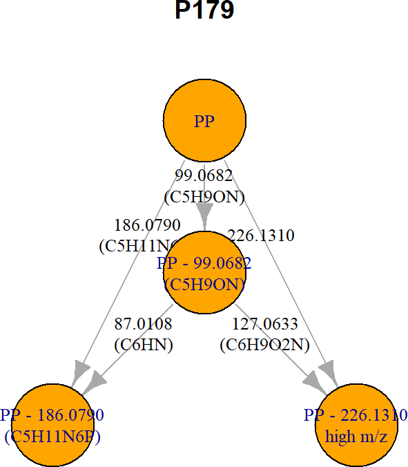

|  | Mz_diff_mean | Mz_diff_min | Mz_diff_max | Formula | Chosen_formula |
| --- | --- | --- | --- | --- | --- |
| 105 | 87.0108 | 87.0061 | 87.0154 | CHO2N3,C6HN,C3H5NS | C6HN |
| 125 | 99.0682 | 99.0635 | 99.0728 | H9O3N3,C5H9ON,C2H13ONS | C5H9ON |
| 161 | 127.0633 | 127.0586 | 127.0679 | H9ON5S,CH9O4N3,C2H5N7,H10ON5P,C6H9O2N,C3H13O2NS,H9O3N5,C5H9ON3,C2H13ON3S | C6H9O2N |
| 215 | 186.0790 | 186.0743 | 186.0837 | H14O7N2S,C5H14O5S,C2H10O6N4,C3H14ON4S2,C3H6O2N8,H15O7N2P,CH11O3N6P,C7H10O4N2,H10O2N8S,C8H6N6,C5H15O5P,C6H11ON4P,C4H14O4N2S,C12H10O2,C5H10N6S,C2H19O5SP,C3H15ON4SP,CH18O4N2S2,CH10O5N6,C9H14O2S,C2H6ON10,… | C5H11N6P |
| 248 | 226.1310 | 226.1263 | 226.1356 | NA | high m/z |

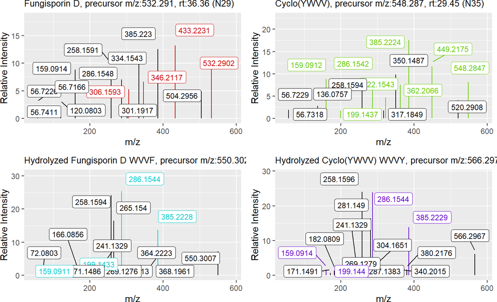

```r
comp4_pattern_id.c <- molnet_patterns.ls[[4]][1, "id"]
plotPatterns(pnordicum.m2l, comp4_pattern_id.c,
             infos_col = c("mz.precursor", "rt", "name", "formula"))
```

This pattern includes an m/z difference of $186.079$, with the possible formula $C_{11}H_{10}ON_2$, that may correspond to a loss of tryptophan, which is indeed included in the peptides.

## 3.6 Beyond molecular networks: discovering new similarities between spectra

The patterns also help discovering new similarities between spectra. Getting back to the $186.079$ m/z difference above, it is now possible to look for this loss in other patterns using the `select` function:

```r
tryptophan_dmz.vc <- findMz(pnordicum.m2l, mz = 186.079, ppm = 15, dmz = 0.01, type = "L")
tryptophan_patterns.ls <- select(pnordicum.m2l, tryptophan_dmz.vc, "P")
tryptophan_patterns.ls
```

```
## $L215
##  [1] "P143" "P160" "P163" "P174" "P178" "P179" "P180" "P181" "P220" "P227"
## [11] "P244" "P254" "P255" "P256"
```

A total of other 14 patterns (including the P179 from the previous section) include this m/z difference. As an example, let us focus on the pattern P181:

|  | mz.precursor | rt | name | formula |
| --- | --- | --- | --- | --- |
| S29 | 532.2908 | 36.36 | Fungisporin D | C30H37N5O4 |
| S35 | 548.2866 | 29.45 | Cyclo(YWVV) | C30H37N5O5 |
| S36 | 550.3015 | 17.09 | Hydrolyzed Fungisporin D VFWV | C30H39N5O5 |
| S37 | 550.3015 | 17.84 | Hydrolyzed Fungisporin D VFWV | C30H39N5O5 |
| S38 | 550.3015 | 18.93 | Hydrolyzed Fungisporin D WVVF | C30H39N5O5 |
| S39 | 566.2965 | 12.26 | Hydrolyzed Cyclo(YWVV)VYWV | C30H39N5O6 |
| S40 | 566.2965 | 13.24 | Hydrolyzed Cyclo(YWVV) WVVY | C30H39N5O6 |

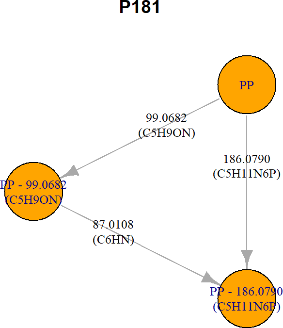

|  | Mz_diff_mean | Mz_diff_min | Mz_diff_max | Formula | Chosen_formula |
| --- | --- | --- | --- | --- | --- |
| 105 | 87.0108 | 87.0061 | 87.0154 | CHO2N3,C6HN,C3H5NS | C6HN |
| 125 | 99.0682 | 99.0635 | 99.0728 | H9O3N3,C5H9ON,C2H13ONS | C5H9ON |
| 215 | 186.0790 | 186.0743 | 186.0837 | H14O7N2S,C5H14O5S,C2H10O6N4,C3H14ON4S2,C3H6O2N8,H15O7N2P,CH11O3N6P,C7H10O4N2,H10O2N8S,C8H6N6,C5H15O5P,C6H11ON4P,C4H14O4N2S,C12H10O2,C5H10N6S,C2H19O5SP,C3H15ON4SP,CH18O4N2S2,CH10O5N6,C9H14O2S,C2H6ON10,… | C5H11N6P |

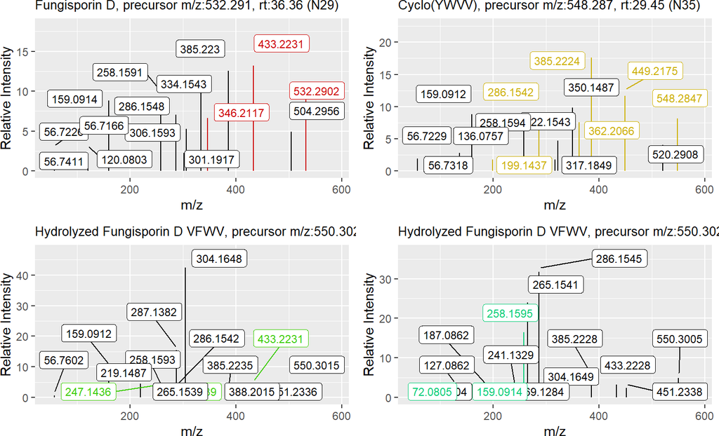

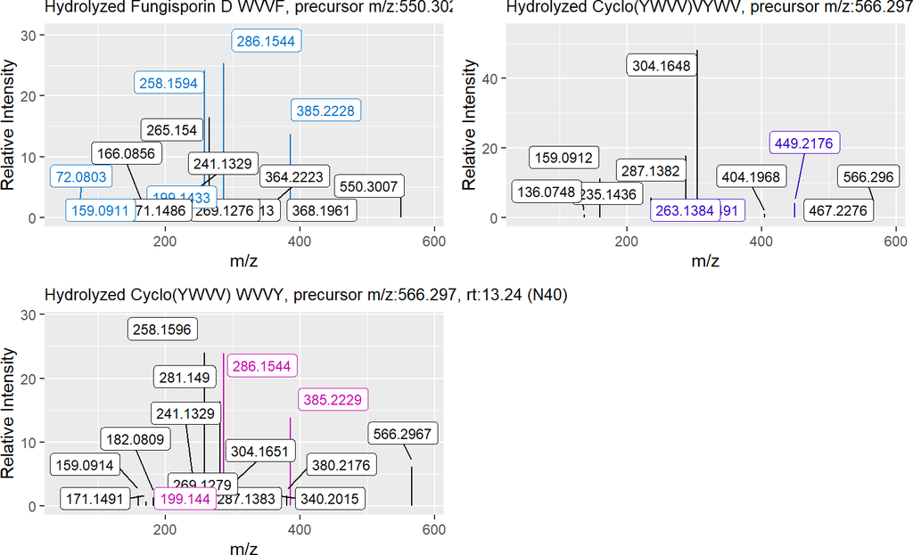

```r
plotPatterns(pnordicum.m2l, tryptophan_patterns.ls[[1]][8],
             infos_col = c("mz.precursor", "rt", "name", "formula"))
```

Interestingly, this pattern is included in 7 spectra, that are not all linked together in the GNPS network, but that were identified by the authors of (Hautbergue et al. 2019) as tetrapeptides containing a tryptophan residue.

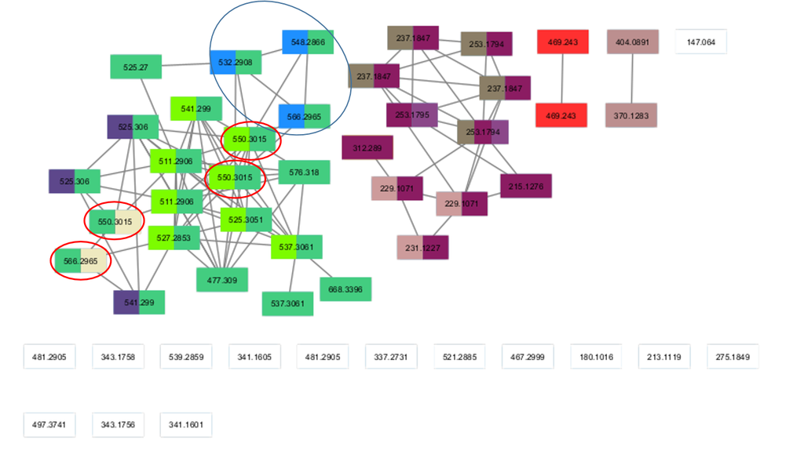

*mineMS2* thus enables to discover new similarities, common to multiple spectra and independent from molecular network threshold, and facilitates their interpretation as fragmentation graphs (Delabrière et al. 2025).

# References

Delabrière, Alexis, Coline Gianfrotta, Sylvain Dechaumet, Annelaure Damont, Thaïs Hautbergue, Pierrick Roger, Emilien L. Jamin, et al. 2025. “mineMS2: Annotation of Spectral Libraries with Exact Fragmentation Patterns,” March. https://doi.org/10.26434/chemrxiv-2025-3c9z1.

Hautbergue, Thais, Emilien L. Jamin, Robin Costantino, Souria Tadrist, Lauriane Meneghetti, Jean-Claude Tabet, Laurent Debrauwer, Isabelle P. Oswald, and Olivier Puel. 2019. “Combination of Isotope Labeling and Molecular Networking of Tandem Mass Spectrometry Data To Reveal 69 Unknown Metabolites Produced by Penicillium Nordicum.” *Analytical Chemistry* 91 (19): 12191–202. https://doi.org/10.1021/acs.analchem.9b01634.

Olivon, Florent, Nicolas Elie, Gwendal Grelier, Fanny Roussi, Marc Litaudon, and David Touboul. 2018. “MetGem Software for the Generation of Molecular Networks Based on the t-SNE Algorithm.” *Analytical Chemistry* 90 (23): 13900–13908. https://doi.org/10.1021/acs.analchem.8b03099.

Shannon, Paul, Andrew Markiel, Owen Ozier, Nitin S Baliga, Jonathan T Wang, Daniel Ramage, Nada Amin, Benno Schwikowski, and Trey Ideker. 2003. “Cytoscape: A Software Environment for Integrated Models of Biomolecular Interaction Networks.” *Genome Research* 13 (11): 2498–2504. https://doi.org/10.1101/gr.1239303.

Watrous, Jeramie, Patrick Roach, Theodore Alexandrov, Brandi S. Heath, Jane Y. Yang, Roland D. Kersten, Menno van der Voort, et al. 2012. “Mass Spectral Molecular Networking of Living Microbial Colonies.” *Proceedings of the National Academy of Sciences* 109 (26): E1743–52. https://doi.org/10.1073/pnas.1203689109.